```python
#import lib
import pandas as pd
from sklearn.model_selection import train_test_split
from sklearn.linear_model import LinearRegression
import matplotlib.pyplot as plt
```

# about the data

StreetEasy is New York City’s leading real estate marketplace — from studios to high-rises, Brooklyn Heights to Harlem.

It has the following columns:

rental_id: rental ID

rent: price of rent in dollars

bedrooms: number of bedrooms

bathrooms: number of bathrooms

size_sqft: size in square feet

min_to_subway: distance from subway station in minutes

floor: floor number

building_age_yrs: building’s age in years

no_fee: does it have a broker fee? (0 for fee, 1 for no fee)

has_roofdeck: does it have a roof deck? (0 for no, 1 for yes)

has_washer_dryer: does it have washer/dryer in unit? (0/1)

has_doorman: does it have a doorman? (0/1)

has_elevator: does it have an elevator? (0/1)

has_dishwasher: does it have a dishwasher (0/1)

has_patio: does it have a patio? (0/1)

has_gym: does the building have a gym? (0/1)

neighborhood: (ex: Greenpoint)

borough: (ex: Brooklyn)

```python
#import the data
df=pd.read_csv('C:/Users/amr/Downloads/manhattan.csv')
```

```python
#show the data
df.head(7)
```

|  | rental_id | rent | bedrooms | bathrooms | size_sqft | min_to_subway | floor | building_age_yrs | no_fee | has_roofdeck | has_washer_dryer | has_doorman | has_elevator | has_dishwasher | has_patio | has_gym | neighborhood | borough |
| --- | --- | --- | --- | --- | --- | --- | --- | --- | --- | --- | --- | --- | --- | --- | --- | --- | --- | --- |
| 0 | 1545 | 2550 | 0.0 | 1 | 480 | 9 | 2.0 | 17 | 1 | 1 | 0 | 0 | 1 | 1 | 0 | 1 | Upper East Side | Manhattan |
| 1 | 2472 | 11500 | 2.0 | 2 | 2000 | 4 | 1.0 | 96 | 0 | 0 | 0 | 0 | 0 | 0 | 0 | 0 | Greenwich Village | Manhattan |
| 2 | 2919 | 4500 | 1.0 | 1 | 916 | 2 | 51.0 | 29 | 0 | 1 | 0 | 1 | 1 | 1 | 0 | 0 | Midtown | Manhattan |
| 3 | 2790 | 4795 | 1.0 | 1 | 975 | 3 | 8.0 | 31 | 0 | 0 | 0 | 1 | 1 | 1 | 0 | 1 | Greenwich Village | Manhattan |
| 4 | 3946 | 17500 | 2.0 | 2 | 4800 | 3 | 4.0 | 136 | 0 | 0 | 0 | 1 | 1 | 1 | 0 | 1 | Soho | Manhattan |
| 5 | 10817 | 3800 | 3.0 | 2 | 1100 | 3 | 5.0 | 101 | 0 | 0 | 0 | 0 | 0 | 0 | 0 | 0 | Central Harlem | Manhattan |
| 6 | 9077 | 1995 | 0.0 | 0 | 600 | 6 | 1.0 | 115 | 0 | 0 | 0 | 0 | 0 | 0 | 0 | 0 | Midtown East | Manhattan |

**split the data into two dataframe**

```python
x=df[[ 'bedrooms', 'bathrooms',
       'size_sqft', 'min_to_subway', 'floor', 'building_age_yrs', 'no_fee',
       'has_roofdeck', 'has_washer_dryer', 'has_doorman', 'has_elevator',
       'has_dishwasher', 'has_patio', 'has_gym',]]

y=df[['rent']]
```

**Use scikit-learn’s train_test_split() method to split x into 80% training set and 20% testing set**

```python
x_train,x_test,y_train,y_test=train_test_split(x,y,train_size=0.8,test_size=0.2,random_state=6)
```

**the shapes of x_train, x_test, y_train, and y_test**

```python
print(x_train.shape)
print(x_test.shape)
print(y_train.shape)
print(y_test.shape)
```

```
(2831, 14)
(708, 14)
(2831, 1)
(708, 1)
```

**Create a Linear Regression model and Fit the model using x_train and y_train.**

```python
mlr=LinearRegression()
mlr.fit(x_train,y_train)
```

```
LinearRegression(copy_X=True, fit_intercept=True, n_jobs=1, normalize=False)
```

**predict y-values from x_test**

```python
y_predict=mlr.predict(x_test)
```

```python
y_predict
```

[output not shown]

[output cut: 653 more lines]

[output not shown]

# experiment

```python
amr=[[2.0,2,2000,4,1.0,96,0,0,0,0,0,0,0,0]]
amr_predict=mlr.predict(amr)
```

```python
print(amr_predict)
```

```
[[ 10247.2577083]]
```

# experiment two

```python
sonny_apartment = [[1, 1, 620, 16, 1, 98, 1, 0, 1, 0, 0, 1, 1, 0]]

predict = mlr.predict(sonny_apartment)

print("Predicted rent: $%.2f" % predict)
```

```
Predicted rent: $2393.58
```

**Create a 2D scatter plot using y_test and y_predict**

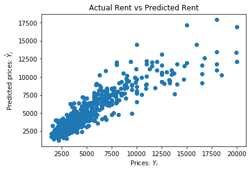

```python
plt.scatter(y_test,y_predict)
plt.xlabel("Prices: $Y_i$")
plt.ylabel("Predicted prices: $\hat{Y}_i$")
plt.title("Actual Rent vs Predicted Rent")

plt.show()
```

```python
print("Train score:")
print(mlr.score(x_train, y_train))
```

```
Train score:
0.772546055982
```

```python
print("Test score:")
print(mlr.score(x_test, y_test))
```

```
Test score:
0.805037197536
```